# Lab 11 Homework

Kyra Kong

2023-02-20

## Instructions

Answer the following questions and complete the exercises in RMarkdown. Please embed all of your code and push your final work to your repository. Your final lab report should be organized, clean, and run free from errors. Remember, you must remove the `#` for the included code chunks to run. Be sure to add your name to the author header above. For any included plots, make sure they are clearly labeled. You are free to use any plot type that you feel best communicates the results of your analysis.

**In this homework, you should make use of the aesthetics you have learned. It’s OK to be flashy!**

Make sure to use the formatting conventions of RMarkdown to make your report neat and clean!

## Load the libraries

```r
library(tidyverse)
library(janitor)
library(here)
library(naniar)
```

## Resources

The idea for this assignment came from [Rebecca Barter’s](http://www.rebeccabarter.com/blog/2017-11-17-ggplot2_tutorial/) ggplot tutorial so if you get stuck this is a good place to have a look.

## Gapminder

For this assignment, we are going to use the dataset [gapminder](https://cran.r-project.org/web/packages/gapminder/index.html). Gapminder includes information about economics, population, and life expectancy from countries all over the world. You will need to install it before use. This is the same data that we will use for midterm 2 so this is good practice.

```r
#install.packages("gapminder")
library("gapminder")
```

## Questions

The questions below are open-ended and have many possible solutions. Your approach should, where appropriate, include numerical summaries and visuals. Be creative; assume you are building an analysis that you would ultimately present to an audience of stakeholders. Feel free to try out different `geoms` if they more clearly present your results.

**1. Use the function(s) of your choice to get an idea of the overall structure of the data frame, including its dimensions, column names, variable classes, etc. As part of this, determine how NA’s are treated in the data.**

```r
gapminder <- data.frame(gapminder)
```

```r
glimpse(gapminder)
```

```
## Rows: 1,704
## Columns: 6
## $ country   <fct> "Afghanistan", "Afghanistan", "Afghanistan", "Afghanistan", …
## $ continent <fct> Asia, Asia, Asia, Asia, Asia, Asia, Asia, Asia, Asia, Asia, …
## $ year      <int> 1952, 1957, 1962, 1967, 1972, 1977, 1982, 1987, 1992, 1997, …
## $ lifeExp   <dbl> 28.801, 30.332, 31.997, 34.020, 36.088, 38.438, 39.854, 40.8…
## $ pop       <int> 8425333, 9240934, 10267083, 11537966, 13079460, 14880372, 12…
## $ gdpPercap <dbl> 779.4453, 820.8530, 853.1007, 836.1971, 739.9811, 786.1134, …
```

```r
structure(gapminder)
```

[output not shown]

[output cut: 1690 more lines]

```r
naniar::miss_var_summary(gapminder)
```

```
## # A tibble: 6 × 3
##   variable  n_miss pct_miss
##   <chr>      <int>    <dbl>
## 1 country        0        0
## 2 continent      0        0
## 3 year           0        0
## 4 lifeExp        0        0
## 5 pop            0        0
## 6 gdpPercap      0        0
```

```r
any_na(gapminder)
```

```
## [1] FALSE
```

There are 1704 observations and 6 variables, the data is tidy and there are no NAs.

**2. Among the interesting variables in gapminder is life expectancy. How has global life expectancy changed between 1952 and 2007?**

```r
names(gapminder)
```

```
## [1] "country"   "continent" "year"      "lifeExp"   "pop"       "gdpPercap"
```

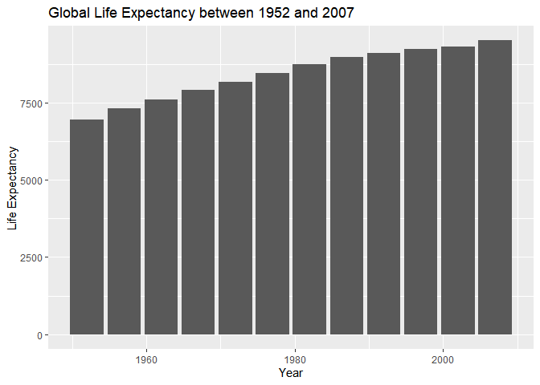

```r
gapminder %>%
  filter(between(year, 1952, 2007)) %>%
  ggplot(aes(x=year, y= lifeExp, group= year))+
  geom_col()+
  labs(title = "Global Life Expectancy between 1952 and 2007", x= "Year", y= "Life Expectancy")
```

**3. How do the distributions of life expectancy compare for the years 1952 and 2007?**

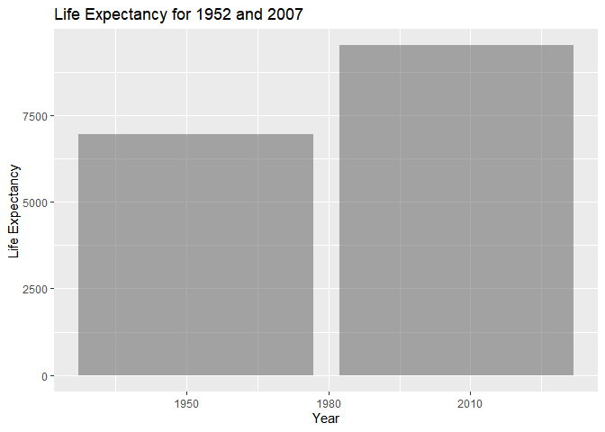

```r
gapminder %>%
  filter(year== 1952| year == 2007) %>%
  ggplot(aes(x = year, y = lifeExp)) +
  geom_col(alpha = 0.5)+
  labs(title ="Life Expectancy for 1952 and 2007", x= "Year", y= "Life Expectancy")
```

**4. Your answer above doesn’t tell the whole story since life expectancy varies by region. Make a summary that shows the min, mean, and max life expectancy by continent for all years represented in the data.**

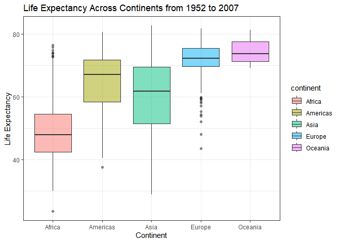

```r
gapminder %>%
  group_by(lifeExp) %>%
  ggplot(aes(x=continent, y= lifeExp, fill= continent))+
  geom_boxplot(alpha =0.5)+
  theme_bw()+
  labs(title= "Life Expectancy Across Continents from 1952 to 2007",
       x= "Continent", y= "Life Expectancy")
```

**5. How has life expectancy changed between 1952-2007 for each continent?**

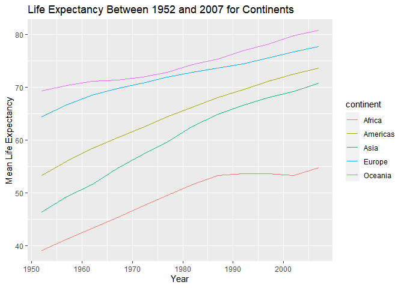

```r
gapminder %>%
  group_by(year,continent) %>%
  summarize(mean=mean(lifeExp)) %>%
  ggplot(aes(x=year, y= mean, group = continent, color =continent))+
  geom_line()+
  labs(title= "Life Expectancy Between 1952 and 2007 for Continents", x= "Year", y= "Mean Life Expectancy")
```

[figure not shown]

```r
gapminder %>%
  filter(continent == "Africa") %>%
  filter(between(year, 1952,2007)) %>%
  ggplot(aes(x=year, y= lifeExp)) +
  geom_col(alpha=0.5, fill= "green")+
  labs(title= "Life Expectancy between 1952 and 2007 for Americas",
       x= "Year", y= "Life Expectancy")+
  theme_bw()
```

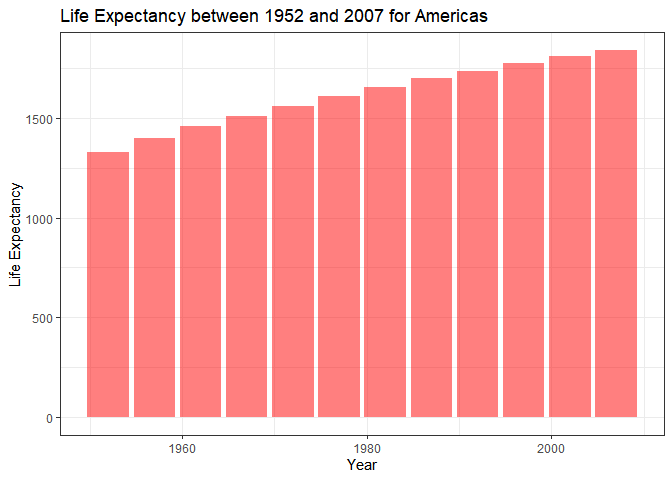

```r
gapminder %>%
  filter(continent == "Americas") %>%
  filter(between(year, 1952,2007)) %>%
  ggplot(aes(x=year, y= lifeExp)) +
  geom_col(alpha=0.5, fill = "red")+
  labs(title= "Life Expectancy between 1952 and 2007 for Americas",
       x= "Year", y= "Life Expectancy")+
  theme_bw()
```

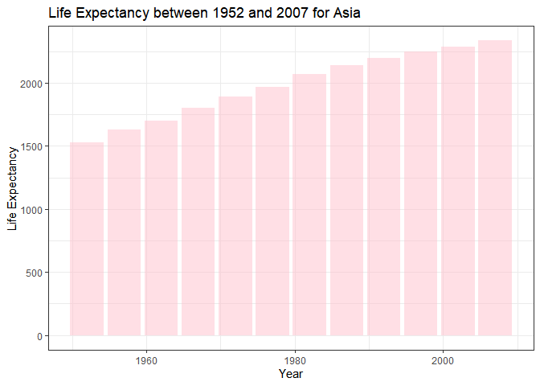

```r
gapminder %>%
  filter(continent == "Asia") %>%
  filter(between(year, 1952,2007)) %>%
  ggplot(aes(x=year, y= lifeExp)) +
  geom_col(alpha=0.5, fill= "pink")+
  labs(title= "Life Expectancy between 1952 and 2007 for Asia",
       x= "Year", y= "Life Expectancy")+
  theme_bw()
```

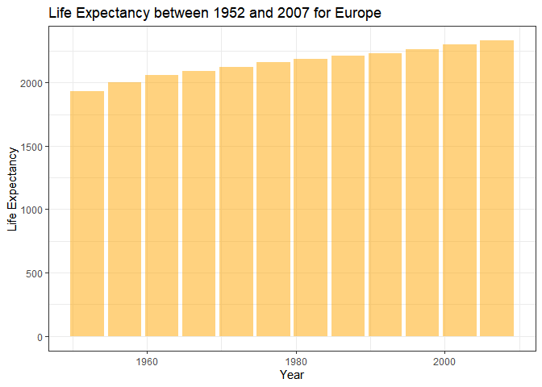

```r
gapminder %>%
  filter(continent == "Europe") %>%
  filter(between(year, 1952,2007)) %>%
  ggplot(aes(x=year, y= lifeExp)) +
  geom_col(alpha=0.5, fill= "orange")+
  labs(title= "Life Expectancy between 1952 and 2007 for Europe",
       x= "Year", y= "Life Expectancy")+
  theme_bw()
```

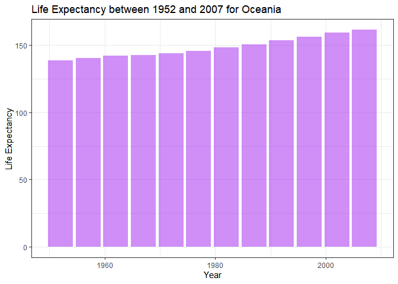

```r
gapminder %>%
  filter(continent == "Oceania") %>%
  filter(between(year, 1952,2007)) %>%
  ggplot(aes(x=year, y= lifeExp)) +
  geom_col(alpha=0.5, fill= "purple")+
  labs(title= "Life Expectancy between 1952 and 2007 for Oceania",
       x= "Year", y= "Life Expectancy")+
  theme_bw()
```

Overall the life expectancies for all the continents increase.

**6. We are interested in the relationship between per capita GDP and life expectancy; i.e. does having more money help you live longer?**

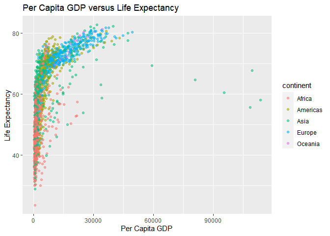

```r
gapminder %>%
  ggplot(aes(x=lifeExp,y=gdpPercap, color=continent))+
  geom_point(alpha =0.5)+
  coord_flip()+
  labs(title= "Per Capita GDP versus Life Expectancy",
       x= "Life Expectancy", y= "Per Capita GDP")
```

**7. Which countries have had the largest population growth since 1952?**

```r
gapminder %>%
  select(country, year, pop) %>%
  filter(year == 1952|year ==2007) %>%
  pivot_wider(names_from = year, names_prefix = "yr_", values_from = pop) %>%
  mutate(growth = yr_2007-yr_1952) %>%
  arrange(desc(growth))
```

```
## # A tibble: 142 × 4
##    country         yr_1952    yr_2007    growth
##    <fct>             <int>      <int>     <int>
##  1 China         556263527 1318683096 762419569
##  2 India         372000000 1110396331 738396331
##  3 United States 157553000  301139947 143586947
##  4 Indonesia      82052000  223547000 141495000
##  5 Brazil         56602560  190010647 133408087
##  6 Pakistan       41346560  169270617 127924057
##  7 Bangladesh     46886859  150448339 103561480
##  8 Nigeria        33119096  135031164 101912068
##  9 Mexico         30144317  108700891  78556574
## 10 Philippines    22438691   91077287  68638596
## # … with 132 more rows
```

```r
options(scipen = 999)
```

```r
gapminder %>%
  select(country, year, pop) %>%
  filter(year == 1952|year ==2007) %>%
  pivot_wider(names_from = year, names_prefix = "yr_", values_from = pop) %>%
  mutate(growth = yr_2007-yr_1952) %>%
  arrange(desc(growth))
```

```
## # A tibble: 142 × 4
##    country         yr_1952    yr_2007    growth
##    <fct>             <int>      <int>     <int>
##  1 China         556263527 1318683096 762419569
##  2 India         372000000 1110396331 738396331
##  3 United States 157553000  301139947 143586947
##  4 Indonesia      82052000  223547000 141495000
##  5 Brazil         56602560  190010647 133408087
##  6 Pakistan       41346560  169270617 127924057
##  7 Bangladesh     46886859  150448339 103561480
##  8 Nigeria        33119096  135031164 101912068
##  9 Mexico         30144317  108700891  78556574
## 10 Philippines    22438691   91077287  68638596
## # … with 132 more rows
```

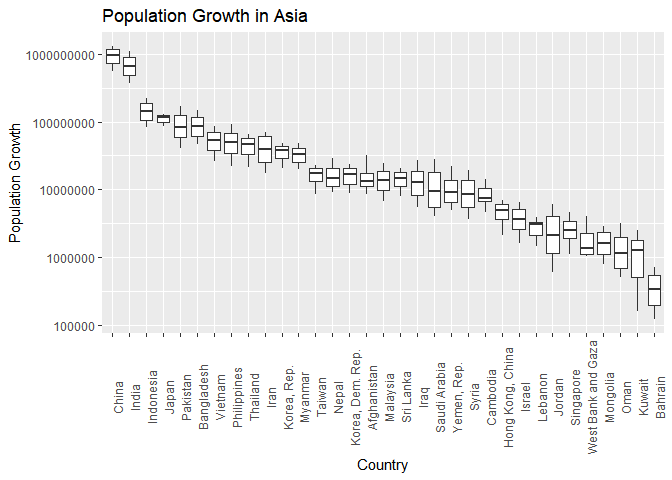

```r
gapminder %>%
  filter(continent == "Asia") %>%
  ggplot(aes(x=reorder(country, - pop),country,y=pop)) +
  scale_y_log10()+
  geom_boxplot()+
    theme(axis.text.x= element_text(angle = 90)) +
  labs(title = "Population Growth in Asia", x= "Country", y= "Population Growth")
```

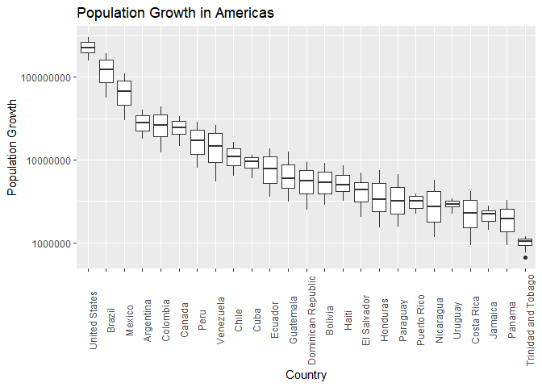

```r
gapminder %>%
  filter(continent == "Americas") %>%
ggplot(aes(x=reorder(country, - pop),country,y=pop)) +
  geom_boxplot()+
  scale_y_log10()+
    theme(axis.text.x= element_text(angle = 90))+
  labs(title= "Population Growth in Americas", x = "Country", y= "Population Growth")
```

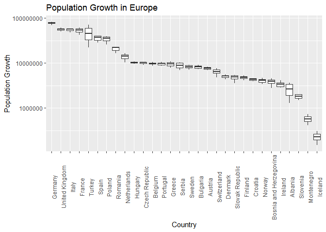

```r
gapminder %>%
  filter(continent == "Europe") %>%
  ggplot(aes(x=reorder(country, - pop),country,y=pop)) +
  geom_boxplot()+
  scale_y_log10()+
    theme(axis.text.x= element_text(angle = 90))+
  labs(title= "Population Growth in Europe", x = "Country", y= "Population Growth")
```

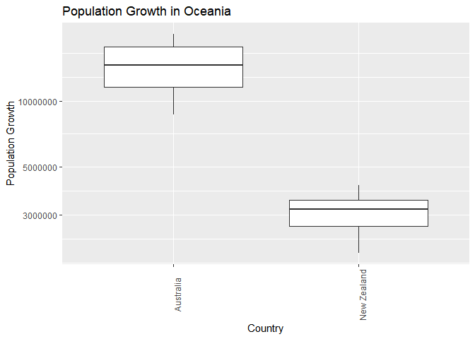

```r
gapminder %>%
  filter(continent == "Oceania") %>%
  ggplot(aes(x=country,y=pop)) +
  scale_y_log10()+
  geom_boxplot()+
    theme(axis.text.x= element_text(angle = 90))+
  labs(title= "Population Growth in Oceania", x = "Country", y= "Population Growth")
```

**8. Use your results from the question above to plot population growth for the top five countries since 1952.**

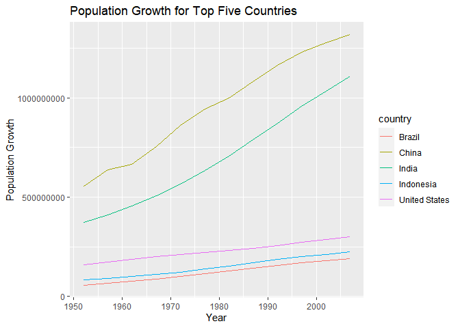

```r
gapminder %>%
  filter(country == "China"| country == "India"| country == "United States"| country== "Indonesia"| country == "Brazil") %>%
  select(country, year, pop) %>%
  ggplot(aes(x=year,y=pop, color = country))+
  geom_line()+
  labs(title = "Population Growth for Top Five Countries",
       x= "Year", y= "Population Growth")
```

**9. How does per-capita GDP growth compare between these same five countries?**

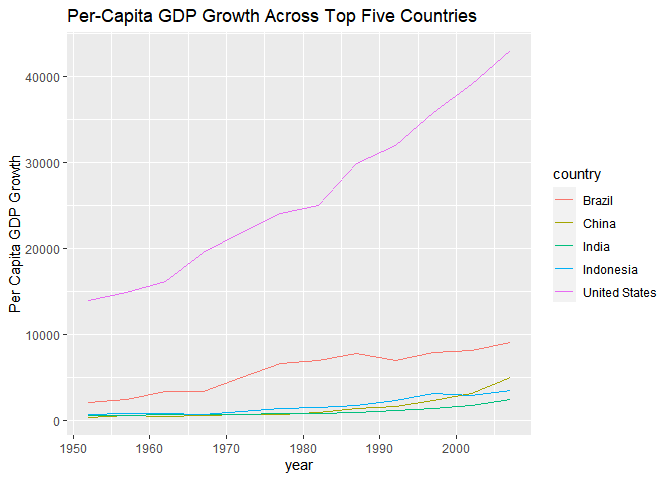

```r
gapminder %>%
  filter(country == "China"| country == "India"| country == "United States" | country == "Indonesia" | country == "Brazil") %>%
  ggplot(aes(x=year, y= gdpPercap, color = country))+
  geom_line()+
  labs(title= "Per-Capita GDP Growth Across Top Five Countries", x= "year", y= "Per Capita GDP Growth")
```

**10. Make one plot of your choice that uses faceting!**

```r
options(scipen=999)
library(gtools)
quartiles2 <-quantcut(gapminder$pop)
table(quartiles2)
```

```
## quartiles2
##    [6e+04,2.79e+06] (2.79e+06,7.02e+06] (7.02e+06,1.96e+07] (1.96e+07,1.32e+09]
##                 426                 426                 426                 426
```

```r
summary(gapminder$pop)
```

```
##       Min.    1st Qu.     Median       Mean    3rd Qu.       Max.
##      60011    2793664    7023596   29601212   19585222 1318683096
```

```r
gapminder <- gapminder %>%
  mutate(range_pop = case_when(pop < 2793664 ~"very_small",
                              pop >= 2793664 & pop <= 7023596 ~"small",
                              pop >=7023596 & pop<=19585222 ~ "medium",
                              pop >=19585222 ~ "large"))
gapminder %>%
  select(range_pop, country, pop)
```

```
##       range_pop                  country        pop
## 1        medium              Afghanistan    8425333
## 2        medium              Afghanistan    9240934
## 3        medium              Afghanistan   10267083
## 4        medium              Afghanistan   11537966
## 5        medium              Afghanistan   13079460
## 6        medium              Afghanistan   14880372
## 7        medium              Afghanistan   12881816
## 8        medium              Afghanistan   13867957
## 9        medium              Afghanistan   16317921
## 10        large              Afghanistan   22227415
## 11        large              Afghanistan   25268405
## 12        large              Afghanistan   31889923
## 13   very_small                  Albania    1282697
## 14   very_small                  Albania    1476505
```

[output cut: 1690 more lines]

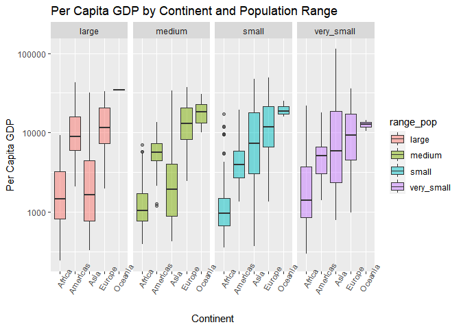

```r
gapminder %>%
  ggplot(aes(x=continent, y= gdpPercap, fill= range_pop))+
  geom_boxplot(alpha=0.5)+
  facet_grid(.~range_pop)+
  scale_y_log10()+
  theme(axis.text.x = element_text(angle=60))+
  labs(title= "Per Capita GDP by Continent and Population Range",
       x= "Continent", y= "Per Capita GDP")
```

## Push your final code to GitHub!

Please be sure that you check the `keep md` file in the knit preferences.